# Biostat 212a Homework 5

Due Mar 16, 2024 @ 11:59PM

Author

Kathy Hoang and 506333118

Published

March 17, 2024

```r
#Clear Environment
rm(list=ls())
```

```r
#load libraries
library(GGally)
library(gtsummary)
library(kernlab)
library(tidyverse)
library(tidymodels)
library(ISLR2)
```

## 1 ISL Exercise 9.7.1 (10pts)

This problem involves hyperplanes in two dimensions. (a) Sketch the hyperplane 1 + 3X1 − X2 = 0. Indicate the set of points for which 1 + 3X1 − X2 > 0, as well as the set of points for which 1 + 3X1 − X2 < 0.

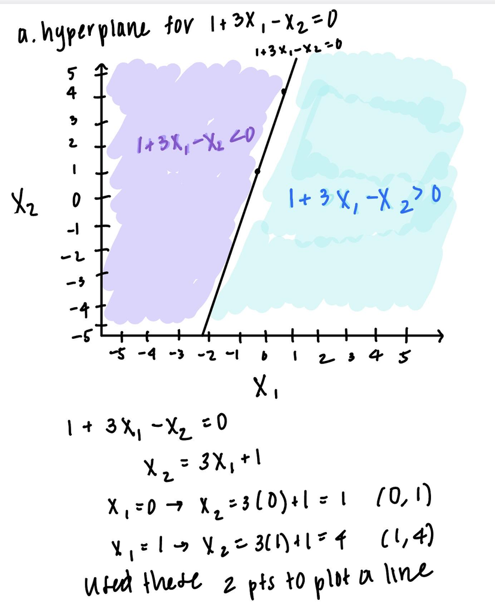

9.7.1.a Hyperplane

2. On the same plot, sketch the hyperplane −2 + X1 + 2X2 = 0. Indicate the set of points for which −2 + X1 + 2X2 > 0, as well as the set of points for which −2 + X1 + 2X2 < 0.

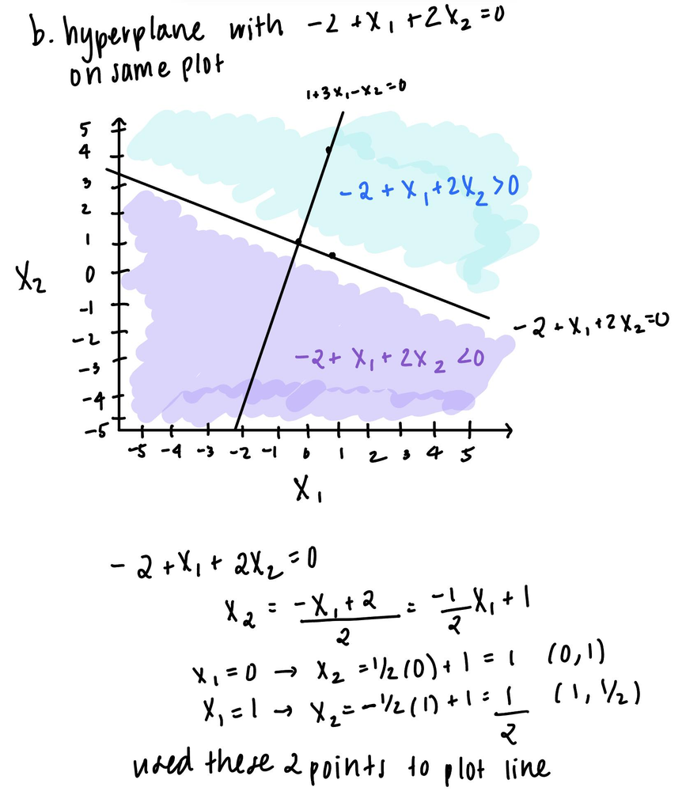

9.7.1.b Hyperplane

## 2 ISL Exercise 9.7.2 (10pts)

We have seen that in p = 2 dimensions, a linear decision boundary takes the form $\beta_0 + \beta_1X_1 + \beta_2X_2 =0$. We now investigate a non-linear decision boundary.

### 2.1 a

1. Sketch the curve $(1 + X_1)^2 + (2 − X_2)^2 = 4:$

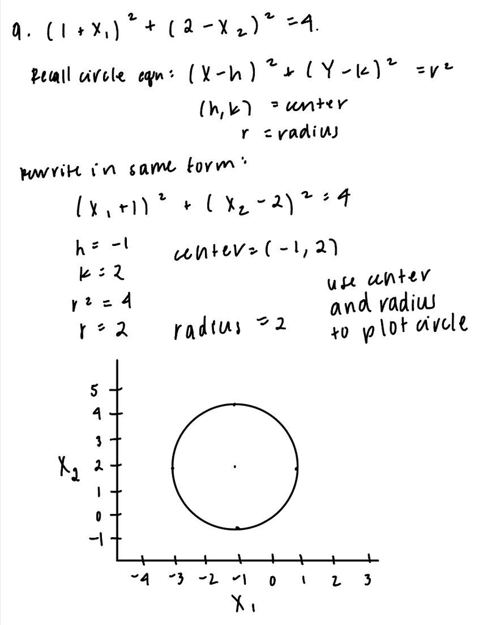

9.7.2.a Curve

### 2.2 b

2. On your sketch, indicate the set of points for which

$(1 + X_1)^2 + (2 − X_2)^2 > 4;$

as well as the set of points for which $(1 + X_1)^2 + (2 − X_2)^2 $\le$ 4:$

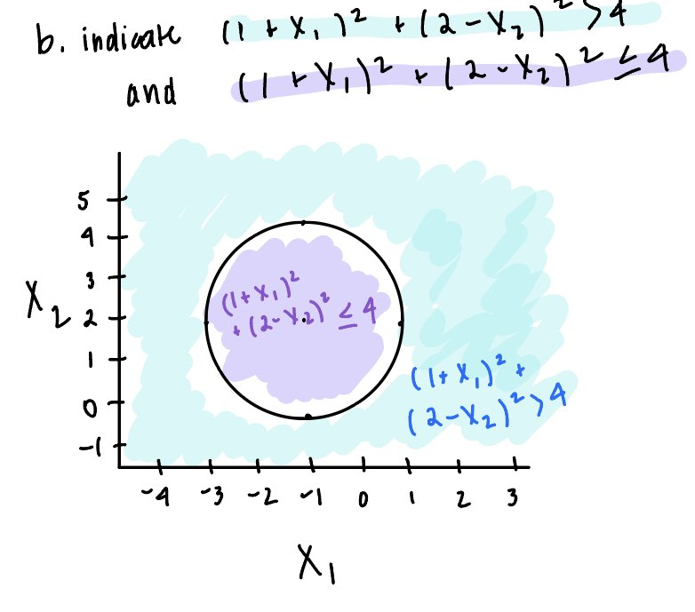

9.7.2.b Set of Points

### 2.3 c

3. Suppose that a classifier assigns an observation to the blue class if $(1 + X_1)^2 + (2 − X_2)^2 > 4;$ and to the red class otherwise. To what class is the observation (0, 0) classified? (−1, 1)? (2, 2)? (3, 8)?

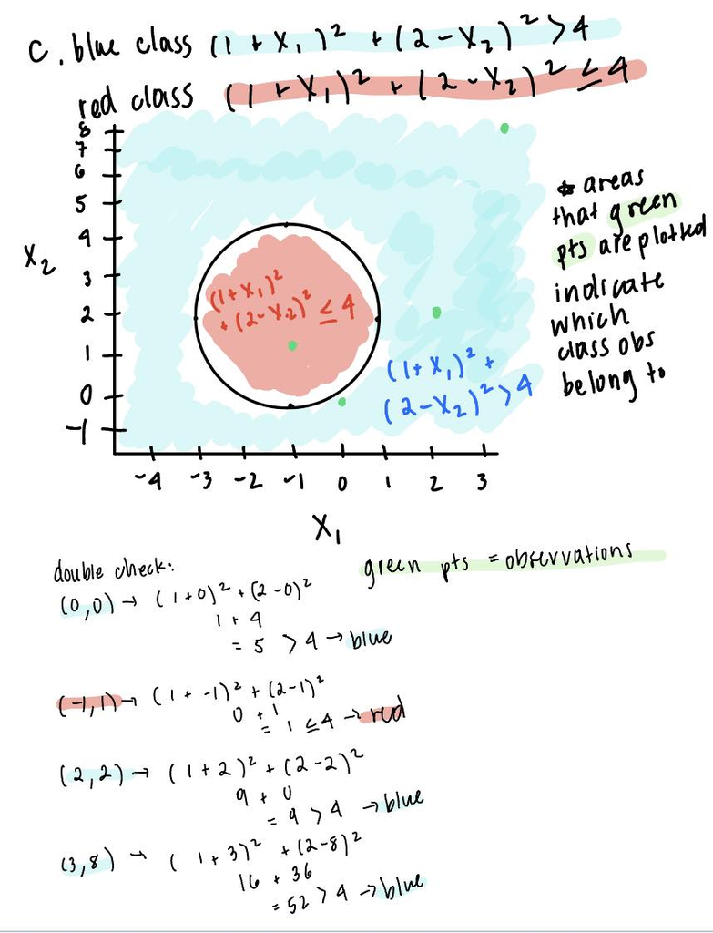

9.7.2.c Classifer for Observations

### 2.4 d

4. Argue that while the decision boundary in (c) is not linear in terms of $X_1$ and $X_2$, it is linear in terms of $X_1$, $X_1^2$, $X_2$, and $X_2^2$.

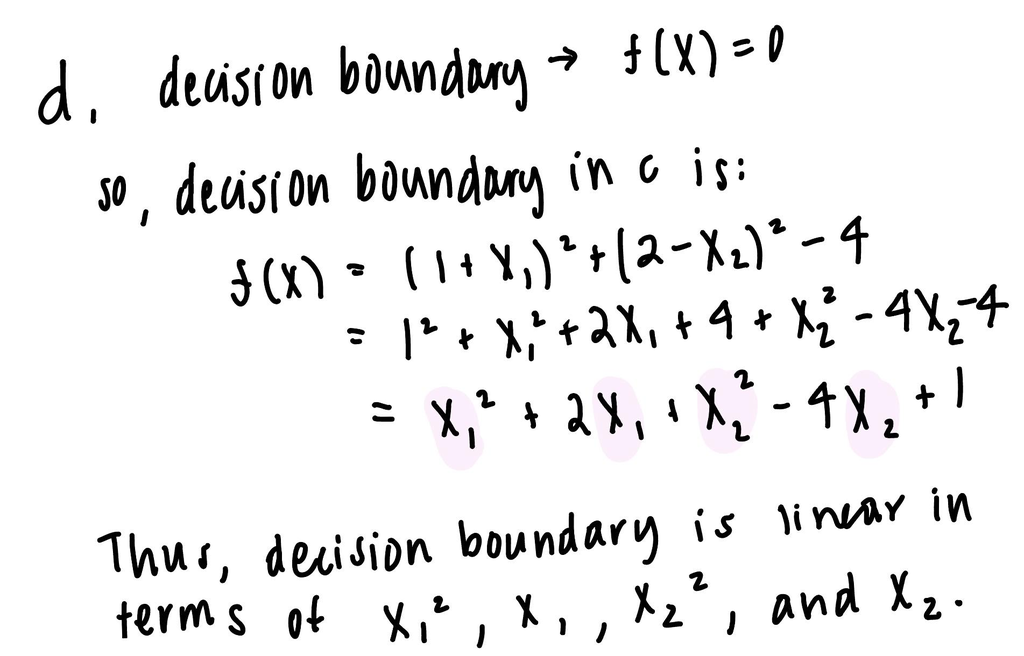

**Written Explanation**

The decision boundary is not linear in terms of $X_1$ and $X_2$ because the terms $X_1^2$ and $X_2^2$ make it quadratic. If it were linear, it would have the form $aX_1 + bX_2 + c = 0$, where a, b, and c are constants.

However, the decision boundary is linear in terms of $X_1$, $X_1^2$, $X_2$, and $X_2^2$ because they are represented in the form of a linear equation: $aX_1 + bX_1^2 + cX_2 + dX_2^2 + e = 0$, where a, b, c, d, and e are constants.

## 3 Support vector machines (SVMs) on the `Carseats` data set (30pts)

Follow the machine learning workflow to train support vector classifier (same as SVM with linear kernel), SVM with polynomial kernel (tune the degree and regularization parameter $C$), and SVM with radial kernel (tune the scale parameter $\gamma$ and regularization parameter $C$) for classifying `Sales<=8` versus `Sales>8`. Use the same seed as in your HW4 for the initial test/train split and compare the final test AUC and accuracy to those methods you tried in HW4.

```r
#load data
carseats_ds <- Carseats
carseats_ds |> tbl_summary()
```

| **Characteristic** | **N = 400**<sup>1</sup> |
| --- | --- |
| Sales | 7.49 (5.39, 9.32) |
| CompPrice | 125 (115, 135) |
| Income | 69 (43, 91) |
| Advertising | 5.0 (0.0, 12.0) |
| Population | 272 (139, 399) |
| Price | 117 (100, 131) |
| ShelveLoc |  |
| Bad | 96 (24%) |
| Good | 85 (21%) |
| Medium | 219 (55%) |
| Age | 55 (40, 66) |
| Education |  |
| 10 | 48 (12%) |
| 11 | 48 (12%) |
| 12 | 49 (12%) |
| 13 | 43 (11%) |
| 14 | 40 (10%) |
| 15 | 36 (9.0%) |
| 16 | 47 (12%) |
| 17 | 49 (12%) |
| 18 | 40 (10%) |
| Urban | 282 (71%) |
| US | 258 (65%) |

<sup>1</sup> Median (IQR); n (%)

```r
#check for null
is.na(carseats_ds) |> colSums()
```

```
      Sales   CompPrice      Income Advertising  Population       Price
          0           0           0           0           0           0
  ShelveLoc         Age   Education       Urban          US
          0           0           0           0           0
```

```r
# Recode Sales as a Factor
carseats_ds$Sales <- factor(ifelse(carseats_ds$Sales > 8, "High", "Low"))
head(carseats_ds,5)
```

```
  Sales CompPrice Income Advertising Population Price ShelveLoc Age Education
1  High       138     73          11        276   120       Bad  42        17
2  High       111     48          16        260    83      Good  65        10
3  High       113     35          10        269    80    Medium  59        12
4   Low       117    100           4        466    97    Medium  55        14
5   Low       141     64           3        340   128       Bad  38        13
  Urban  US
1   Yes Yes
2   Yes Yes
3   Yes Yes
4   Yes Yes
5   Yes  No
```

```r
#Split Data
set.seed(212)

carseats_split <- initial_split(
  carseats_ds,
  prop = 0.75,
  strata = Sales)
carseats_split
```

```
<Training/Testing/Total>
<300/100/400>
```

```r
carseats_train <- training(carseats_split)
carseats_test <- testing(carseats_split)

dim(carseats_train)
```

```
[1] 300  11
```

```r
dim(carseats_test)
```

```
[1] 100  11
```

```r
#Preprocess Data and Recipe
svm_carseats_recipe <- recipe(
  Sales ~ .,
  data = carseats_train) |>
  step_dummy(all_nominal_predictors()) |>
  step_zv(all_numeric_predictors()) |>
  step_normalize(all_numeric_predictors())
```

### 3.1 SVM with linear kernel

```r
svm_linear_mod <-
  svm_linear(
    mode = "classification",
    cost = tune(),
    #degree = 1 #linear
  ) %>%
  set_engine("kernlab")
svm_linear_mod
```

```
Linear Support Vector Machine Model Specification (classification)

Main Arguments:
  cost = tune()

Computational engine: kernlab
```

```r
#Bundle
svm_linear_wf <- workflow() %>%
  add_recipe(svm_carseats_recipe) %>%
  add_model(svm_linear_mod)

#Tune
param_grid_linear <- grid_regular(
  cost(range = c(-2, 3)), #tune cost (C)
  #degree = 1, #bc linear
  levels = c(5)
  )
```

```r
#Cross-Validation
set.seed(212)

svm_linear_folds <- vfold_cv(carseats_train, v = 5)

#Fit C-V
svm_linear_fit <- svm_linear_wf %>%
  tune_grid(
    resamples = svm_linear_folds,
    grid = param_grid_linear,
    metrics = metric_set(roc_auc, accuracy)
    )

svm_linear_fit
```

```
# Tuning results
# 5-fold cross-validation
# A tibble: 5 × 4
  splits           id    .metrics          .notes
  <list>           <chr> <list>            <list>
1 <split [240/60]> Fold1 <tibble [10 × 5]> <tibble [0 × 3]>
2 <split [240/60]> Fold2 <tibble [10 × 5]> <tibble [0 × 3]>
3 <split [240/60]> Fold3 <tibble [10 × 5]> <tibble [0 × 3]>
4 <split [240/60]> Fold4 <tibble [10 × 5]> <tibble [0 × 3]>
5 <split [240/60]> Fold5 <tibble [10 × 5]> <tibble [0 × 3]>
```

```
# A tibble: 10 × 7
    cost .metric  .estimator  mean     n std_err .config
   <dbl> <chr>    <chr>      <dbl> <int>   <dbl> <chr>
 1 0.25  accuracy binary     0.893     5  0.0256 Preprocessor1_Model1
 2 0.25  roc_auc  binary     0.958     5  0.0127 Preprocessor1_Model1
 3 0.595 accuracy binary     0.893     5  0.0208 Preprocessor1_Model2
 4 0.595 roc_auc  binary     0.963     5  0.0117 Preprocessor1_Model2
 5 1.41  accuracy binary     0.903     5  0.0255 Preprocessor1_Model3
 6 1.41  roc_auc  binary     0.961     5  0.0122 Preprocessor1_Model3
 7 3.36  accuracy binary     0.893     5  0.0227 Preprocessor1_Model4
 8 3.36  roc_auc  binary     0.961     5  0.0117 Preprocessor1_Model4
 9 8     accuracy binary     0.903     5  0.0207 Preprocessor1_Model5
10 8     roc_auc  binary     0.959     5  0.0121 Preprocessor1_Model5
```

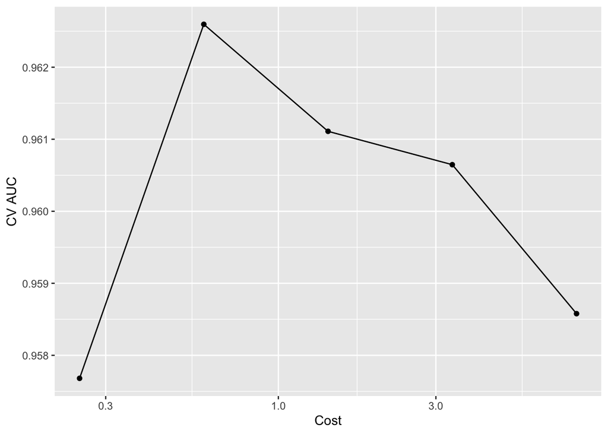

```r
#Cost
svm_linear_fit %>%
  collect_metrics() %>%
  print(width = Inf) %>%
  filter(.metric == "roc_auc" ) %>%
  ggplot(mapping = aes(x = cost, y = mean)) +
  geom_point() +
  geom_line() +
  labs(x = "Cost", y = "CV AUC") +
  scale_x_log10()
```

```r
#Best Model
svm_linear_fit %>%
  show_best("roc_auc")
```

```
# A tibble: 5 × 7
   cost .metric .estimator  mean     n std_err .config
  <dbl> <chr>   <chr>      <dbl> <int>   <dbl> <chr>
1 0.595 roc_auc binary     0.963     5  0.0117 Preprocessor1_Model2
2 1.41  roc_auc binary     0.961     5  0.0122 Preprocessor1_Model3
3 3.36  roc_auc binary     0.961     5  0.0117 Preprocessor1_Model4
4 8     roc_auc binary     0.959     5  0.0121 Preprocessor1_Model5
5 0.25  roc_auc binary     0.958     5  0.0127 Preprocessor1_Model1
```

```r
best_svm_linear <- svm_linear_fit %>%
  select_best("roc_auc")

#Final Model
final_svm_linear <- svm_linear_wf %>%
  finalize_workflow(
    best_svm_linear
  )

#Fit Final Model
final_svm_lin_fit <- final_svm_linear %>%
  fit(data = carseats_train)
final_svm_lin_fit
```

```
══ Workflow [trained] ══════════════════════════════════════════════════════════
Preprocessor: Recipe
Model: svm_linear()

── Preprocessor ────────────────────────────────────────────────────────────────
3 Recipe Steps

• step_dummy()
• step_zv()
• step_normalize()

── Model ───────────────────────────────────────────────────────────────────────
Support Vector Machine object of class "ksvm"

SV type: C-svc  (classification)
 parameter : cost C = 0.59460355750136

Linear (vanilla) kernel function.

Number of Support Vectors : 90

Objective Function Value : -45.1719
Training error : 0.09
Probability model included.
```

```r
#Predict
final_svm_preds <- final_svm_lin_fit %>%
  predict(new_data = carseats_test) %>%
  bind_cols(carseats_test)
final_svm_preds
```

```
# A tibble: 100 × 12
   .pred_class Sales CompPrice Income Advertising Population Price ShelveLoc
 * <fct>       <fct>     <dbl>  <dbl>       <dbl>      <dbl> <dbl> <fct>
 1 Low         High        138     73          11        276   120 Bad
 2 Low         Low         132    113           0        131   124 Medium
 3 High        High        121     78           9        150   100 Bad
 4 High        High        107    117          11        148   118 Good
 5 High        High        139     32           0        176    82 Good
 6 Low         High        107    115          11        496   131 Good
 7 Low         Low         104     99          15        226   102 Bad
 8 Low         Low         107     32          12        236   137 Good
 9 Low         Low         121     41           5        412   110 Medium
10 Low         Low         130     60           0        144   138 Bad
# ℹ 90 more rows
# ℹ 4 more variables: Age <dbl>, Education <dbl>, Urban <fct>, US <fct>
```

### 3.2 SVM with polynomial kernel

Tune the degree and regularization parameter $C$.

```r
#Model
svm_mod <-
  svm_poly(
    mode = "classification",
    cost = tune(),
    degree = tune(),
    # scale_factor = tune()
  ) %>%
  set_engine("kernlab")
svm_mod
```

```
Polynomial Support Vector Machine Model Specification (classification)

Main Arguments:
  cost = tune()
  degree = tune()

Computational engine: kernlab
```

```r
#Bundle
svm_wf <- workflow() %>%
  add_recipe(svm_carseats_recipe) %>%
  add_model(svm_mod)
svm_wf
```

```
══ Workflow ════════════════════════════════════════════════════════════════════
Preprocessor: Recipe
Model: svm_poly()

── Preprocessor ────────────────────────────────────────────────────────────────
3 Recipe Steps

• step_dummy()
• step_zv()
• step_normalize()

── Model ───────────────────────────────────────────────────────────────────────
Polynomial Support Vector Machine Model Specification (classification)

Main Arguments:
  cost = tune()
  degree = tune()

Computational engine: kernlab
```

```r
#Tune
param_grid <- grid_regular(
  cost(range = c(-2,3)), #tune cost (C)
  #cost(range = c(-3,3)), #tune cost (C)
  #on a logarithmic scale
  #10-3 to 10^3 (0.0001, 0.01, 0.1, 1, 100, 1000)
  degree(range = c(1, 5)), #tune degrees 1-5
  #scale_factor(range = c(-1, 1)),
  levels = c(5)
  )
param_grid
```

```
# A tibble: 25 × 2
    cost degree
   <dbl>  <dbl>
 1 0.25       1
 2 0.595      1
 3 1.41       1
 4 3.36       1
 5 8          1
 6 0.25       2
 7 0.595      2
 8 1.41       2
 9 3.36       2
10 8          2
# ℹ 15 more rows
```

```r
#Cross-Valisdation
set.seed(212)
svm_folds <- vfold_cv(carseats_train, v = 5)
svm_folds
```

```
#  5-fold cross-validation
# A tibble: 5 × 2
  splits           id
  <list>           <chr>
1 <split [240/60]> Fold1
2 <split [240/60]> Fold2
3 <split [240/60]> Fold3
4 <split [240/60]> Fold4
5 <split [240/60]> Fold5
```

```r
#Fit C-V
svm_fit <- svm_wf %>%
  tune_grid(
    resamples = svm_folds,
    grid = param_grid,
    metrics = metric_set(roc_auc, accuracy)
    )
svm_fit
```

```
# Tuning results
# 5-fold cross-validation
# A tibble: 5 × 4
  splits           id    .metrics          .notes
  <list>           <chr> <list>            <list>
1 <split [240/60]> Fold1 <tibble [50 × 6]> <tibble [0 × 3]>
2 <split [240/60]> Fold2 <tibble [50 × 6]> <tibble [0 × 3]>
3 <split [240/60]> Fold3 <tibble [50 × 6]> <tibble [0 × 3]>
4 <split [240/60]> Fold4 <tibble [50 × 6]> <tibble [0 × 3]>
5 <split [240/60]> Fold5 <tibble [50 × 6]> <tibble [0 × 3]>
```

```
# A tibble: 50 × 8
    cost degree .metric  .estimator  mean     n std_err .config
   <dbl>  <dbl> <chr>    <chr>      <dbl> <int>   <dbl> <chr>
 1 0.25       1 accuracy binary     0.893     5  0.0256 Preprocessor1_Model01
 2 0.25       1 roc_auc  binary     0.958     5  0.0127 Preprocessor1_Model01
 3 0.595      1 accuracy binary     0.893     5  0.0208 Preprocessor1_Model02
 4 0.595      1 roc_auc  binary     0.963     5  0.0117 Preprocessor1_Model02
 5 1.41       1 accuracy binary     0.903     5  0.0255 Preprocessor1_Model03
 6 1.41       1 roc_auc  binary     0.961     5  0.0122 Preprocessor1_Model03
 7 3.36       1 accuracy binary     0.893     5  0.0227 Preprocessor1_Model04
 8 3.36       1 roc_auc  binary     0.961     5  0.0117 Preprocessor1_Model04
 9 8          1 accuracy binary     0.903     5  0.0207 Preprocessor1_Model05
10 8          1 roc_auc  binary     0.959     5  0.0121 Preprocessor1_Model05
# ℹ 40 more rows
```

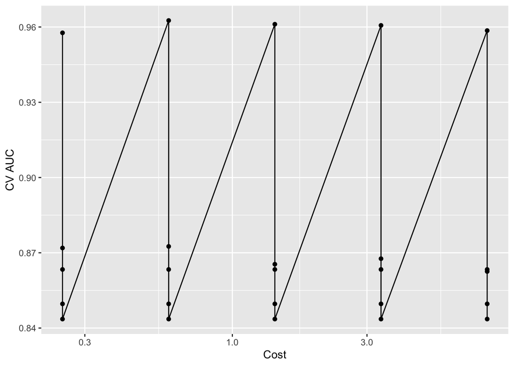

```r
#Cost
svm_fit %>%
  collect_metrics() %>%
  print(width = Inf) %>%
  filter(.metric == "roc_auc" ) %>%
  ggplot(mapping = aes(x = cost, y = mean)) +
  geom_point() +
  geom_line() +
  labs(x = "Cost", y = "CV AUC") +
  scale_x_log10()
```

```
# A tibble: 50 × 8
    cost degree .metric  .estimator  mean     n std_err .config
   <dbl>  <dbl> <chr>    <chr>      <dbl> <int>   <dbl> <chr>
 1 0.25       1 accuracy binary     0.893     5  0.0256 Preprocessor1_Model01
 2 0.25       1 roc_auc  binary     0.958     5  0.0127 Preprocessor1_Model01
 3 0.595      1 accuracy binary     0.893     5  0.0208 Preprocessor1_Model02
 4 0.595      1 roc_auc  binary     0.963     5  0.0117 Preprocessor1_Model02
 5 1.41       1 accuracy binary     0.903     5  0.0255 Preprocessor1_Model03
 6 1.41       1 roc_auc  binary     0.961     5  0.0122 Preprocessor1_Model03
 7 3.36       1 accuracy binary     0.893     5  0.0227 Preprocessor1_Model04
 8 3.36       1 roc_auc  binary     0.961     5  0.0117 Preprocessor1_Model04
 9 8          1 accuracy binary     0.903     5  0.0207 Preprocessor1_Model05
10 8          1 roc_auc  binary     0.959     5  0.0121 Preprocessor1_Model05
# ℹ 40 more rows
```

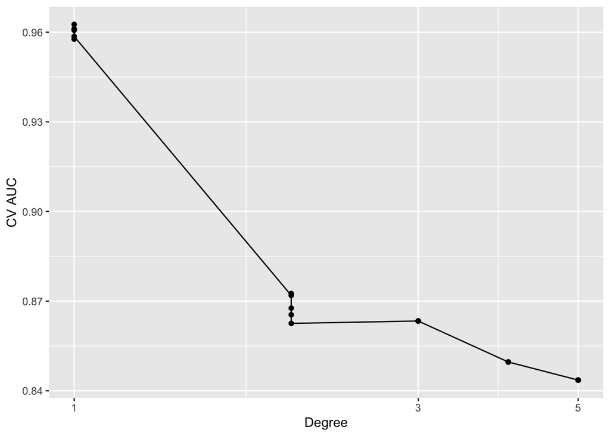

```r
#Degree
svm_fit %>%
  collect_metrics() %>%
  print(width = Inf) %>%
  filter(.metric == "roc_auc" ) %>%
  ggplot(mapping = aes(x = degree, y = mean)) +
  geom_point() +
  geom_line() +
  labs(x = "Degree", y = "CV AUC") +
  scale_x_log10()
```

```
# A tibble: 50 × 8
    cost degree .metric  .estimator  mean     n std_err .config
   <dbl>  <dbl> <chr>    <chr>      <dbl> <int>   <dbl> <chr>
 1 0.25       1 accuracy binary     0.893     5  0.0256 Preprocessor1_Model01
 2 0.25       1 roc_auc  binary     0.958     5  0.0127 Preprocessor1_Model01
 3 0.595      1 accuracy binary     0.893     5  0.0208 Preprocessor1_Model02
 4 0.595      1 roc_auc  binary     0.963     5  0.0117 Preprocessor1_Model02
 5 1.41       1 accuracy binary     0.903     5  0.0255 Preprocessor1_Model03
 6 1.41       1 roc_auc  binary     0.961     5  0.0122 Preprocessor1_Model03
 7 3.36       1 accuracy binary     0.893     5  0.0227 Preprocessor1_Model04
 8 3.36       1 roc_auc  binary     0.961     5  0.0117 Preprocessor1_Model04
 9 8          1 accuracy binary     0.903     5  0.0207 Preprocessor1_Model05
10 8          1 roc_auc  binary     0.959     5  0.0121 Preprocessor1_Model05
# ℹ 40 more rows
```

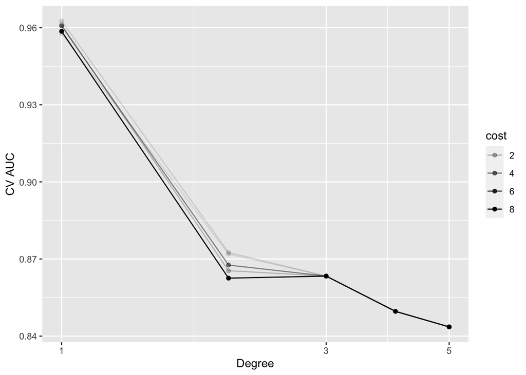

```r
#Additional Plots - (better graphs mentioned in OH)

#Degree on x-axis, grouped by cost
svm_fit %>%
  collect_metrics() %>%
  print(width = Inf) %>%
  filter(.metric == "roc_auc") %>%
  ggplot(mapping = aes(x = degree, y = mean, alpha = cost)) +
  geom_point() +
  geom_line(aes(group = cost)) +
  labs(x = "Degree", y = "CV AUC") +
  scale_x_log10()
```

```
# A tibble: 50 × 8
    cost degree .metric  .estimator  mean     n std_err .config
   <dbl>  <dbl> <chr>    <chr>      <dbl> <int>   <dbl> <chr>
 1 0.25       1 accuracy binary     0.893     5  0.0256 Preprocessor1_Model01
 2 0.25       1 roc_auc  binary     0.958     5  0.0127 Preprocessor1_Model01
 3 0.595      1 accuracy binary     0.893     5  0.0208 Preprocessor1_Model02
 4 0.595      1 roc_auc  binary     0.963     5  0.0117 Preprocessor1_Model02
 5 1.41       1 accuracy binary     0.903     5  0.0255 Preprocessor1_Model03
 6 1.41       1 roc_auc  binary     0.961     5  0.0122 Preprocessor1_Model03
 7 3.36       1 accuracy binary     0.893     5  0.0227 Preprocessor1_Model04
 8 3.36       1 roc_auc  binary     0.961     5  0.0117 Preprocessor1_Model04
 9 8          1 accuracy binary     0.903     5  0.0207 Preprocessor1_Model05
10 8          1 roc_auc  binary     0.959     5  0.0121 Preprocessor1_Model05
# ℹ 40 more rows
```

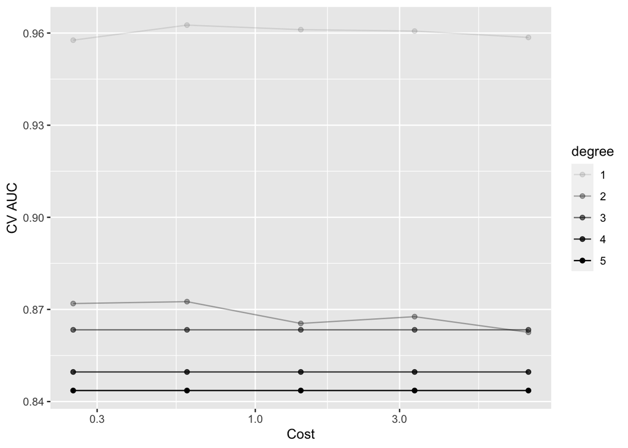

```r
#Cost on x-axis, grouped by degree
svm_fit %>%
  collect_metrics() %>%
  print(width = Inf) %>%
  filter(.metric == "roc_auc") %>%
  ggplot(mapping = aes(x = cost, y = mean, alpha = degree)) +
  geom_point() +
  geom_line(aes(group = degree)) +
  labs(x = "Cost", y = "CV AUC") +
  scale_x_log10()
```

```r
#Best Model
svm_fit %>%
  show_best("roc_auc")
```

```
# A tibble: 5 × 8
   cost degree .metric .estimator  mean     n std_err .config
  <dbl>  <dbl> <chr>   <chr>      <dbl> <int>   <dbl> <chr>
1 0.595      1 roc_auc binary     0.963     5  0.0117 Preprocessor1_Model02
2 1.41       1 roc_auc binary     0.961     5  0.0122 Preprocessor1_Model03
3 3.36       1 roc_auc binary     0.961     5  0.0117 Preprocessor1_Model04
4 8          1 roc_auc binary     0.959     5  0.0121 Preprocessor1_Model05
5 0.25       1 roc_auc binary     0.958     5  0.0127 Preprocessor1_Model01
```

```r
best_svm <- svm_fit %>%
  select_best("roc_auc")
best_svm
```

```
# A tibble: 1 × 3
   cost degree .config
  <dbl>  <dbl> <chr>
1 0.595      1 Preprocessor1_Model02
```

```r
#Final Model
final_svm <- svm_wf %>%
  finalize_workflow(
    best_svm
  )
final_svm
```

```
══ Workflow ════════════════════════════════════════════════════════════════════
Preprocessor: Recipe
Model: svm_poly()

── Preprocessor ────────────────────────────────────────────────────────────────
3 Recipe Steps

• step_dummy()
• step_zv()
• step_normalize()

── Model ───────────────────────────────────────────────────────────────────────
Polynomial Support Vector Machine Model Specification (classification)

Main Arguments:
  cost = 0.59460355750136
  degree = 1

Computational engine: kernlab
```

```r
#Fit Final Model
final_svm_fit <- final_svm %>%
  fit(data = carseats_train)
final_svm_fit
```

```
══ Workflow [trained] ══════════════════════════════════════════════════════════
Preprocessor: Recipe
Model: svm_poly()

── Preprocessor ────────────────────────────────────────────────────────────────
3 Recipe Steps

• step_dummy()
• step_zv()
• step_normalize()

── Model ───────────────────────────────────────────────────────────────────────
Support Vector Machine object of class "ksvm"

SV type: C-svc  (classification)
 parameter : cost C = 0.59460355750136

Polynomial kernel function.
 Hyperparameters : degree =  1  scale =  1  offset =  1

Number of Support Vectors : 90

Objective Function Value : -45.172
Training error : 0.09
Probability model included.
```

```r
#Predict
final_svm_preds <- final_svm_fit %>%
  predict(new_data = carseats_test) %>%
  bind_cols(carseats_test)
final_svm_preds
```

```
# A tibble: 100 × 12
   .pred_class Sales CompPrice Income Advertising Population Price ShelveLoc
 * <fct>       <fct>     <dbl>  <dbl>       <dbl>      <dbl> <dbl> <fct>
 1 Low         High        138     73          11        276   120 Bad
 2 Low         Low         132    113           0        131   124 Medium
 3 High        High        121     78           9        150   100 Bad
 4 High        High        107    117          11        148   118 Good
 5 High        High        139     32           0        176    82 Good
 6 Low         High        107    115          11        496   131 Good
 7 Low         Low         104     99          15        226   102 Bad
 8 Low         Low         107     32          12        236   137 Good
 9 Low         Low         121     41           5        412   110 Medium
10 Low         Low         130     60           0        144   138 Bad
# ℹ 90 more rows
# ℹ 4 more variables: Age <dbl>, Education <dbl>, Urban <fct>, US <fct>
```

### 3.3 SVM with radial kernel

```r
svm_radial_mod <-
  svm_rbf(
    mode = "classification",
    cost = tune(),
    rbf_sigma = tune()
  ) %>%
  set_engine("kernlab")
```

```r
#Bundle
svm_radial_wf <- workflow() %>%
  add_recipe(svm_carseats_recipe) %>%
  add_model(svm_radial_mod)
```

```r
#Tune
param_grid_radial <- grid_regular(
  #cost(range = c(-2, 2)), #tune cost (C)
  cost(range = c(-3,5)), #tune cost (C)
  rbf_sigma(range = c(-4, -2)), #tune scale
  levels = c(5)
  )
```

```r
#Cross-Validation
set.seed(212)

svm_radial_folds <- vfold_cv(carseats_train, v = 5)

#Fit C-V
svm_radial_fit <- svm_radial_wf %>%
  tune_grid(
    resamples = svm_radial_folds,
    grid = param_grid_radial,
    metrics = metric_set(roc_auc, accuracy)
    )
svm_radial_fit
```

```
# Tuning results
# 5-fold cross-validation
# A tibble: 5 × 4
  splits           id    .metrics          .notes
  <list>           <chr> <list>            <list>
1 <split [240/60]> Fold1 <tibble [50 × 6]> <tibble [0 × 3]>
2 <split [240/60]> Fold2 <tibble [50 × 6]> <tibble [0 × 3]>
3 <split [240/60]> Fold3 <tibble [50 × 6]> <tibble [0 × 3]>
4 <split [240/60]> Fold4 <tibble [50 × 6]> <tibble [0 × 3]>
5 <split [240/60]> Fold5 <tibble [50 × 6]> <tibble [0 × 3]>
```

```
# A tibble: 50 × 8
     cost rbf_sigma .metric  .estimator  mean     n std_err
    <dbl>     <dbl> <chr>    <chr>      <dbl> <int>   <dbl>
 1  0.125    0.0001 accuracy binary     0.59      5  0.0319
 2  0.125    0.0001 roc_auc  binary     0.886     5  0.0200
 3  0.5      0.0001 accuracy binary     0.59      5  0.0319
 4  0.5      0.0001 roc_auc  binary     0.893     5  0.0199
 5  2        0.0001 accuracy binary     0.59      5  0.0319
 6  2        0.0001 roc_auc  binary     0.892     5  0.0198
 7  8        0.0001 accuracy binary     0.59      5  0.0319
 8  8        0.0001 roc_auc  binary     0.891     5  0.0201
 9 32        0.0001 accuracy binary     0.78      5  0.0363
10 32        0.0001 roc_auc  binary     0.897     5  0.0199
   .config
   <chr>
 1 Preprocessor1_Model01
 2 Preprocessor1_Model01
 3 Preprocessor1_Model02
 4 Preprocessor1_Model02
 5 Preprocessor1_Model03
 6 Preprocessor1_Model03
 7 Preprocessor1_Model04
 8 Preprocessor1_Model04
 9 Preprocessor1_Model05
10 Preprocessor1_Model05
# ℹ 40 more rows
```

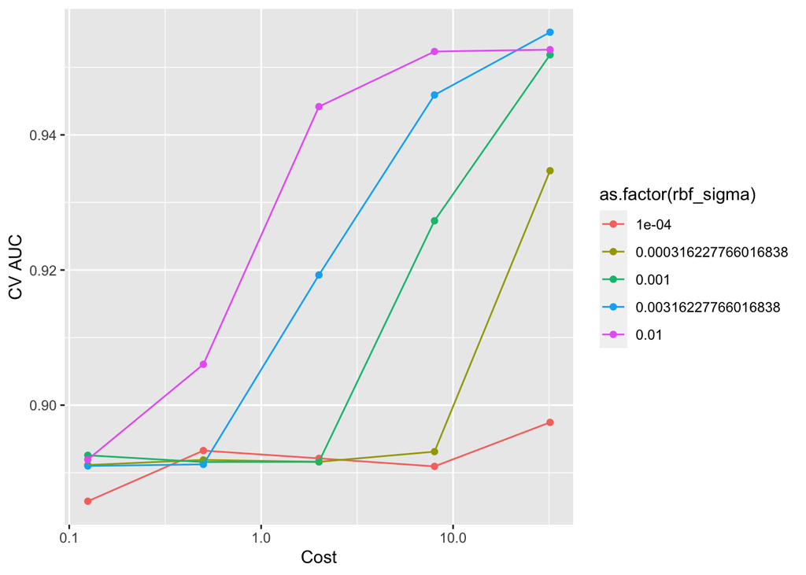

```r
svm_radial_fit %>%
  collect_metrics() %>%
  print(width = Inf) %>%
  filter(.metric == "roc_auc" ) %>%
  ggplot(mapping = aes(x = cost, y = mean, color = as.factor(rbf_sigma))) +
  geom_point() +
  geom_line() +
  labs(x = "Cost", y = "CV AUC") +
  scale_x_log10()
```

### 3.4 HW4 Comparisons

**Answer**

Compared to the methods used in HW4, the SVM with linear kernel, SVM with polynomial kernel, and SVM with radial kernel seem to perform better overall with a higher AUC. The SVM with linear kernel (degree = 1) has the highest AUC above 0.96. The next highest AUC was achieved by the SVM with radial kernel, with an AUC score over 0.95, which was reached by the rbf_sigma parameter of 0.00316 (blue line).

In HW4, the Regression Tree model’s highest AUC was only slightly over 0.8, and the Random Forest model’s highest AUC was just under 0.91. However, the Gradient Boosting had the highest AUC score of about 0.93, but was still under 0.95 so it performed worse than the SVMs above.

Sources:

Intuitive explanation on Tuning Cost and Gamma Parameters https://scikit-learn.org/stable/auto_examples/svm/plot_rbf_parameters.html#sphx-glr-auto-examples-svm-plot-rbf-parameters-py

The degree parameter controls the flexibility of the decision boundary. Higher degree kernels yield a more flexible decision boundary. https://stats.stackexchange.com/questions/348318/degree-parameter-for-svm-polynomial-kernel

## 4 Bonus (10pts)

Let
$$f(X) = \beta_0 + \beta_1 X_1 + \cdots + \beta_p X_p = \beta_0 + \beta^T X.$$
Then $f(X)=0$ defines a hyperplane in $\mathbb{R}^p$. Show that $f(x)$ is proportional to the signed distance of a point $x$ to the hyperplane $f(X) = 0$.

$$
$$\begin{aligned}
&f(X) = \beta_0 + \beta^T X \\
\\
&\text{1.Subtract from both sides: } \beta_0 \\
&f(X) = \beta_0 + \beta^T X \\
&f(X) - \beta_0 = \beta^T X \\
\\
&\text{2. For any X_0 in the hyperplane f(X_0) =0} \\
&f(X_0) -\beta_0 = \beta^T X_0 \\
\\
&\text{3. Set f(x) = 0} \\
&0 -\beta_0 = \beta^T X_0 \\
&-\beta_0 = \beta^T X_0 \\
\\
&\text{The signed distance of any point x from the hyperplane f(x)=0 is given
by} \\
&\frac{1}{||\beta||}(\beta^Tx - \beta^Tx_0) \\
&= \frac{1}{||\beta||}(\beta^Tx + x_0) \\
&= \frac{1}{||\beta||}(f(x)) \\
&\text{where} \\
&||\beta|| = \sqrt{\sum_{j=1}^{p} \beta_j^2}\\
\\
&\text{Therefore, f(x) is proportional to the signed distance of a point x to
the hyperplane f(X) = 0.} \\
\end{aligned}$$